# DSM5006-DONEM SONU DEGERLENDIRME ODEVI

MELİS MERVE DOGANCAY

6/15/2020

## Analizler için kullanılan paketler:

Öncelikle analizler için gerekli olan paketler yüklendi.

```r
library(tidyverse)
library(magrittr)
library(lubridate)
library(leaflet)
```

## Verinin Yüklenmesi:

Analizde, John Hopkins Üniversitesi tarafından sağlanan covid-19 pandemisine ait ülke bazlı verileri https://github.com/CSSEGISandData/COVID-19/tree/master/csse_covid_19_data/csse_covid_19_time_series klasöründe yer alan time_series_covid19_confirmed_global.csv , time_series_covid19_deaths_global.csv ve time_series_covid19_recovered_global.csv dosyalarında yer alan veriler data.frame nesnelerine aktarılarak kullanılmıştır.

```r
data1.confirmed<- read.csv("https://raw.githubusercontent.com/CSSEGISandData/COVID-19/master/csse_covid_19_data/csse_covid_19_time_series/time_series_covid19_confirmed_global.csv", header = T)
data1.deaths <- read.csv("https://raw.githubusercontent.com/CSSEGISandData/COVID-19/master/csse_covid_19_data/csse_covid_19_time_series/time_series_covid19_deaths_global.csv",header=T)
data1.recovered <- read.csv("https://raw.githubusercontent.com/CSSEGISandData/COVID-19/master/csse_covid_19_data/csse_covid_19_time_series/time_series_covid19_recovered_global.csv",header=T)
```

```r
#head(data1.confirmed,5)
#head(data1.deaths,5)
#head(data1.recovered,5)
```

## Verinin Hazırlanışı:

Sırasıyla verinin hazırlanma aşamasında izlenen adımlar aşağıda belirtilmiştir:

1. Verinin analizinde kullanılmayacak olan Province.State, Lat ve Long değişkenleri veriden çıkartıldı ve yeni bir nesneye(veriler.onayli) aktarıldı.
2. Country.Region değişkeninin adı ulke olarak değiştirildi.
3. Bu verilerde tarih bilgisi sütunlarda yer almaktadır. Dolayısıyla veri geniş biçimden uzun biçime ve aynı zamanda tarihler Date formatına dönüştürüldü.

```r
veriler.onayli <- data1.confirmed %>% select(-c(Province.State, Lat, Long))
veriler.onayli %<>% rename(ulke=Country.Region)
veriler.onayli %<>% gather(key=tarih, value=sayi, -ulke)
n.col <- ncol(data1.confirmed)
tarihler <- names(data1.confirmed)[5:n.col] %>% substr(2,8) %>% mdy()
range(tarihler)
```

```
## [1] "2020-01-22" "2020-06-22"
```

```r
veriler.onayli %<>% mutate(tarih = tarih %>% substr(2,8) %>% mdy())
head(veriler.onayli,8)
```

```
##                  ulke      tarih sayi
## 1         Afghanistan 2020-01-22    0
## 2             Albania 2020-01-22    0
## 3             Algeria 2020-01-22    0
## 4             Andorra 2020-01-22    0
## 5              Angola 2020-01-22    0
## 6 Antigua and Barbuda 2020-01-22    0
## 7           Argentina 2020-01-22    0
## 8             Armenia 2020-01-22    0
```

Yukarıda yapılan bütün işlemler data1.deaths ve data1.recovered veri nesneleri için de yapıldı.

```r
veriler.vefat <- data1.deaths %>% select(-c(Province.State, Lat, Long))
veriler.vefat %<>% rename(ulke=Country.Region)
veriler.vefat %<>% gather(key=tarih, value=sayi, -ulke)
veriler.vefat %<>% mutate(tarih = tarih %>% substr(2,8) %>% mdy())
head(veriler.vefat,8)
```

```
##                  ulke      tarih sayi
## 1         Afghanistan 2020-01-22    0
## 2             Albania 2020-01-22    0
## 3             Algeria 2020-01-22    0
## 4             Andorra 2020-01-22    0
## 5              Angola 2020-01-22    0
## 6 Antigua and Barbuda 2020-01-22    0
## 7           Argentina 2020-01-22    0
## 8             Armenia 2020-01-22    0
```

```r
veriler.iyilesen <- data1.recovered %>% select(-c(Province.State, Lat, Long))
veriler.iyilesen %<>% rename(ulke=Country.Region)
veriler.iyilesen %<>% gather(key=tarih, value=sayi, -ulke)
veriler.iyilesen %<>% mutate(tarih = tarih %>% substr(2,8) %>% mdy())
head(veriler.iyilesen,8)
```

```
##                  ulke      tarih sayi
## 1         Afghanistan 2020-01-22    0
## 2             Albania 2020-01-22    0
## 3             Algeria 2020-01-22    0
## 4             Andorra 2020-01-22    0
## 5              Angola 2020-01-22    0
## 6 Antigua and Barbuda 2020-01-22    0
## 7           Argentina 2020-01-22    0
## 8             Armenia 2020-01-22    0
```

$\bullet$ Üç dosyada ayrı ayrı verilen verileri ülke ve tarih bilgisi tutarlı olacak şekilde tek bir veri nesnesinde birleştirildi. İşlemler sonucunda tüm veriler tek nesnede ulke, tarih, onaylanan_sayi, vefat_sayi, iyilesen_sayi gibi değişkenler belirtildi. Yapılan değişiklikler aşağıda ayrıntılı bir şekilde anlatılmıştır.

1. Aynı ülke ve tarih için birden fazla satır bulunmakta dolayısıyla öncelikle bu durum düzeltildi ve aynı zamanda ulke ve tarih değişkenlerine göre sayılar toplandı. Sonrasında kullanılacak olan merge fonksiyonu için nesneyi data.frame formatında tuttuk. Bu işlem üç veri nesnesi içinde yapıldı. Aynı zamanda önceden sayi olarak belirtilen değişkenlerin isimleri de değiştirildi.

```r
veriler.onayli %<>% group_by(ulke, tarih) %>%
  summarise(sayi=sum(sayi, na.rm=T)) %>% as.data.frame()

veriler.vefat %<>% group_by(ulke, tarih) %>%
  summarise(sayi=sum(sayi, na.rm=T)) %>% as.data.frame()

veriler.iyilesen %<>% group_by(ulke, tarih) %>%
  summarise(sayi=sum(sayi, na.rm=T)) %>% as.data.frame()

veriler.onayli %<>% rename(olgu.sayi=sayi)
veriler.vefat %<>% rename(vefat.sayi=sayi)
veriler.iyilesen %<>% rename(iyilesen.sayi=sayi)
```

2. Merge fonksiyonu ile üç ayrı veri nesnesi tek bir veri nesnesinde birleştirildi.

```r
veriler <- veriler.onayli %>% merge(veriler.vefat, all=T) %>% merge(veriler.iyilesen, all=T)
```

$\bullet$ Ülkelere ait veriler tarihlere göre toplandı, tüm dünya için günlük olgu.sayi, vefat.sayi, iyilesen.sayi değerleri elde edildi.

```r
n1 <- length(tarihler)

g.olgu.sayi <- c()
for( i in 1:n1){ g.olgu.sayi[i]<- filter(veriler,veriler$tarih==tarihler[i]) %>%
  summarise(sayi=sum(olgu.sayi, na.rm=T)) %>% as.data.frame()
}
g.olgu.sayi <- as.data.frame(g.olgu.sayi)
colnames(g.olgu.sayi) <- tarihler
g.olgu.sayi %<>% gather(key=tarih,value = sayi)

g.vefat.sayi <- c()
for( i in 1:n1){g.vefat.sayi[i] <- filter(veriler,veriler$tarih==tarihler[i]) %>%
  summarise(sayi=sum(vefat.sayi, na.rm=T)) %>% as.data.frame()
}
g.vefat.sayi <- as.data.frame(g.vefat.sayi)
colnames(g.vefat.sayi) <- tarihler
g.vefat.sayi %<>% gather(key=tarih,value = sayi)


g.iyilesen.sayi <- c()
for( i in 1:n1){g.iyilesen.sayi[i] <- filter(veriler,veriler$tarih==tarihler[i]) %>%
  summarise(sayi=sum(iyilesen.sayi, na.rm=T)) %>% as.data.frame()
}
g.iyilesen.sayi <- as.data.frame(g.iyilesen.sayi)
colnames(g.iyilesen.sayi) <- tarihler
g.iyilesen.sayi %<>% gather(key=tarih,value = sayi)

g.olgu.sayi %<>% rename(olgu.sayi=sayi)
g.vefat.sayi %<>% rename(vefat.sayi=sayi)
g.iyilesen.sayi %<>% rename(iyilesen.sayi=sayi)
```

$\bullet$ Dunya adında yeni değişken oluşturuldu ve tarihlere göre günlük olgu sayisi(g.olgu.sayi), günlük vefat sayisi(g.vefat.sayi), günlük iyileşen sayisi(g.iyilesen.sayi) elde edildi. Sonrasında daha önceden oluşturulan veriler adlı veri nesnesi ile merge fonksiyonu kullanılarak birleştirildi.

```r
Dunya <- rep("Dunya",n1)
g.veriler<-   g.olgu.sayi %>% merge(g.vefat.sayi, all=T) %>% merge(g.iyilesen.sayi, all=T) %<>% cbind(Dunya)
g.veriler %<>% rename(ulke=Dunya)
g.veriler$tarih <- tarihler
#str(g.veriler)

g.veriler <- g.veriler[,c(5,1,2,3,4)]

veriler <- g.veriler %<>% merge(veriler,all=T)
```

$\bullet$ Yapılan tüm bu işlemler sonrasında veriye yeni değişkenler eklendi. Veriye değişken eklenirken mutate fonksiyonu kullanıldı.

1. Aktif vaka sayısını gösteren aktif.olgu değişkeni eklendi.(olgu.sayi-vefat.sayi-iyilesen.sayi)
2. Veriler ülke ve tarihe göre arrange fonksiyonu kullaılarak sıralandı.
3. Her bir gün için yeni.olgu, yeni.vefat, yeni.iyilesen sayıları hesaplandı ve verilere eklendi.
4. Yukarıda beliritilen işlemler sonucunda veride oluşan tutarsızlıklar düzenlendi.
5. 100*vefat.sayi/(vefat.sayi+iyilesen.sayi) oranını kullanarak ust.mortalite.oran, 100*vefat.sayi/olgu.sayi oranını kullanarak alt.mortalite.oran, 100*yeni.vefat/(yeni.vefat+yeni.iyilesen) oranını kullanarak gunluk.oran değişkenleri hesaplandı ve veriye eklendi. Veride oluşan tutarsızlıklar düzenlendi.

```r
##a
veriler <-  mutate(veriler,aktif.olgu=olgu.sayi -  vefat.sayi - iyilesen.sayi)

##b
veriler %<>% arrange(ulke,tarih)

##c
n <- nrow(veriler)
gun1 <- min(veriler$tarih)

veriler <- mutate(veriler,yeni.olgu= ifelse(tarih == gun1, NA, olgu.sayi-lag(olgu.sayi,n=1)),
                  yeni.vefat = ifelse(tarih== gun1, NA, vefat.sayi - lag(vefat.sayi, n=1)),
                  yeni.iyilesen = ifelse(tarih == gun1, NA, iyilesen.sayi - lag(iyilesen.sayi, n=1)))

##d
veriler[is.na(veriler)] <- 0

#which(veriler$yeni.iyilesen<=-1)

veriler$yeni.olgu <- ifelse(veriler$yeni.olgu<=-1,0,veriler$yeni.olgu)
veriler$yeni.iyilesen <- ifelse(veriler$yeni.iyilesen<=-1,0,veriler$yeni.iyilesen)
veriler$yeni.vefat <- ifelse(veriler$yeni.vefat<=-1,0,veriler$yeni.vefat)

##e

veriler<- mutate(veriler,ust.mortalite.oran=100*vefat.sayi/(vefat.sayi+iyilesen.sayi))
veriler <- mutate(veriler,alt.mortalite.oran=100*vefat.sayi/olgu.sayi)
veriler <- mutate(veriler,gunluk.oran=100*yeni.vefat/(yeni.vefat+yeni.iyilesen))

veriler$ust.mortalite.oran <- ifelse(veriler$ust.mortalite.oran=="NaN",0,veriler$ust.mortalite.oran)
veriler$alt.mortalite.oran <- ifelse(veriler$alt.mortalite.oran=="NaN",0,veriler$alt.mortalite.oran)
veriler$gunluk.oran <- ifelse(veriler$gunluk.oran=="NaN",0,veriler$gunluk.oran)
```

$\bullet$ Bir dünya haritası üzerinde ülkelerin olgu sayıları, vefat sayıları ve iyileşen sayılarını gösteren grafik elde edilmiştir.

```r
x <- data1.confirmed
x$confirmed <- x[,ncol(x)]
x <- x %>% select(c(Country.Region,Province.State,Lat,Long,confirmed)) %>%
    mutate(txt=paste0(Country.Region,' - ',Province.State,':',confirmed))
y <- data1.deaths
y$deaths <- y[,ncol(y)]
y <- y %>% select(c(Country.Region,Province.State,Lat,Long,deaths)) %>%
  mutate(txt=paste0(Country.Region,' - ',Province.State,':',deaths))
z <- data1.recovered
z$recovered <- z[,ncol(z)]
z <- z %>% select(c(Country.Region,Province.State,Lat,Long,recovered)) %>%
  mutate(txt=paste0(Country.Region,' - ',Province.State,':',recovered))


m <- leaflet(width=900,height=400) %>% addTiles()



worldmap <- m %>% addCircleMarkers(x$Long,x$Lat,radius = 0.03*sqrt(x$confirmed),
                                   stroke = F,color = "red",
                                   fillOpacity = 0.3,popup  = c(x$txt,paste("<b><a>", x$Country.Region,"<b><a>","<br/>" ,x$Province.State,"<br/>",'Olgu sayısı=',x$confirmed,"<br/>",
                                                                            'Vefat sayısı=',y$deaths,"<br/>",
                                                                            'İyileşen sayısı=',z$recovered,"<br/>")),
                                   popupOptions = popupOptions(minWidth = 200,maxHeight = 400, closeButton=F, closeOnClick=F),
                                   labelOptions = labelOptions(direction = "top",textsize='15px',noHide = TRUE
                                   ))
worldmap
```

[interactive chart not shown]

$\bullet$ Türkiye için covid-19 değerlerine bakmak istersek aşağıda gösterildiği gibidir. Vefat eden kişi sayılarına bakıldığında azalmanın devam ettiğini görebiliriz. Aktif olgu sayısı, Türkiye’de Haziran ayının başında başlayan normalleşme dolayısıyla Haziran ayının ortasından itibaren tekrar artışa geçtiği görülmektedir. Aynı şekilde yeni olgu sayısı da Haziran ayının 12’sinden itibaren 1000 olgunun üzerinde seyir etmektedir.

```r
veriler[veriler$ulke=="Turkey",]
```

```
##         ulke      tarih olgu.sayi vefat.sayi iyilesen.sayi aktif.olgu
## 26623 Turkey 2020-01-22         0          0             0          0
## 26624 Turkey 2020-01-23         0          0             0          0
## 26625 Turkey 2020-01-24         0          0             0          0
## 26626 Turkey 2020-01-25         0          0             0          0
## 26627 Turkey 2020-01-26         0          0             0          0
## 26628 Turkey 2020-01-27         0          0             0          0
## 26629 Turkey 2020-01-28         0          0             0          0
## 26630 Turkey 2020-01-29         0          0             0          0
## 26631 Turkey 2020-01-30         0          0             0          0
## 26632 Turkey 2020-01-31         0          0             0          0
## 26633 Turkey 2020-02-01         0          0             0          0
## 26634 Turkey 2020-02-02         0          0             0          0
## 26635 Turkey 2020-02-03         0          0             0          0
## 26636 Turkey 2020-02-04         0          0             0          0
```

[output cut: 447 more lines]

$\bullet$ Dünyada covid-19 verilerinde toplam olgu sayısına göre sıralama yapıldığında ilk 20 ülke bu şekildedir.

```r
veri.son.hepsi <- veriler %>% filter(tarih==max(tarih)) %>% select(ulke,tarih,olgu.sayi,yeni.olgu,aktif.olgu,iyilesen.sayi,vefat.sayi,yeni.vefat, olum.oranı=alt.mortalite.oran) %>% mutate(sıralama=dense_rank(desc(olgu.sayi)))

k <- 20

top.ulke <- veri.son.hepsi %>% filter(sıralama<=k+1) %>% arrange(sıralama) %>% pull(ulke) %>% as.character()
```

$\bullet$ İlk 20 ülkenin toplam olgu sayıları, toplam vefat sayıları, ölüm oranları, yeni olgu sayıları ve yeni vefat sayılarını gösteren grafikler elde edilmiştir.

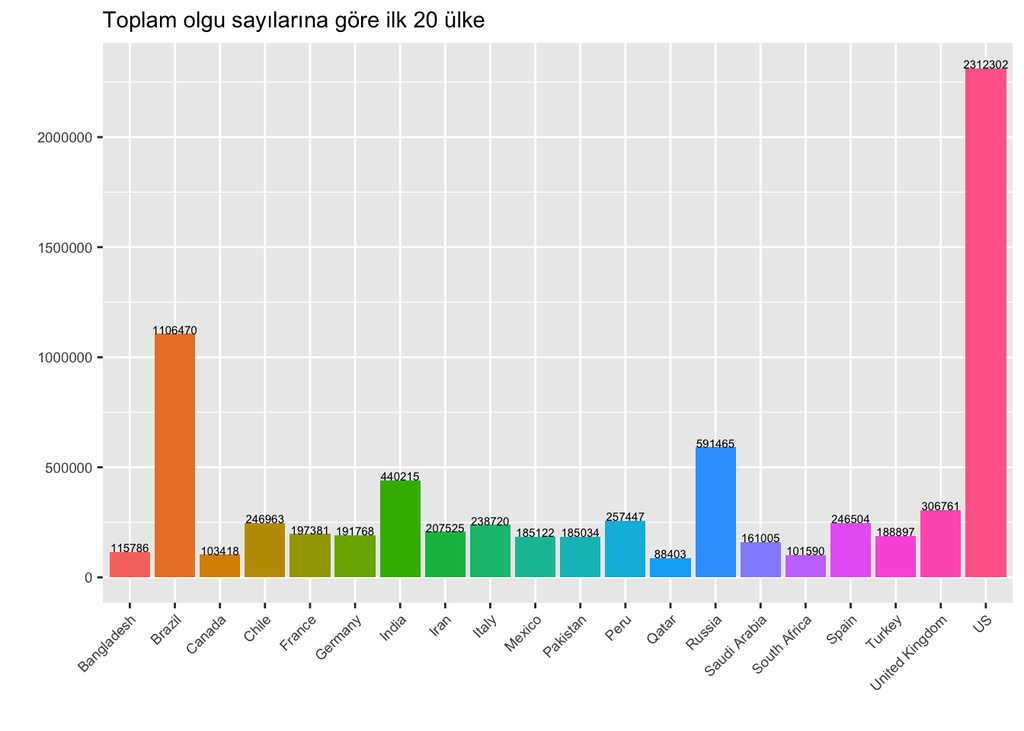

```r
ilk20 <- veri.son.hepsi %>% filter(sıralama<=k+1) %>% arrange(sıralama)  %>% setdiff('Dunya') %>% as.data.frame()

ilk20[-1,] %>%  ggplot(aes(x=ulke,y=olgu.sayi,fill=ulke,group=ulke)) +
  geom_bar(stat = 'identity') + geom_text(aes(label=olgu.sayi,y=olgu.sayi),size=2,vjust=0) +
  xlab("") + ylab('') + labs(title = paste0('Toplam olgu sayılarına göre ilk 20 ülke ')) +
      scale_fill_discrete(name='ulke',labels=aes(olgu.sayi)) +
  theme(legend.title = element_blank(),legend.position = 'none',plot.title = element_text(size=11),axis.text = element_text(size=7),axis.text.x = element_text(angle=45,hjust = 1))
```

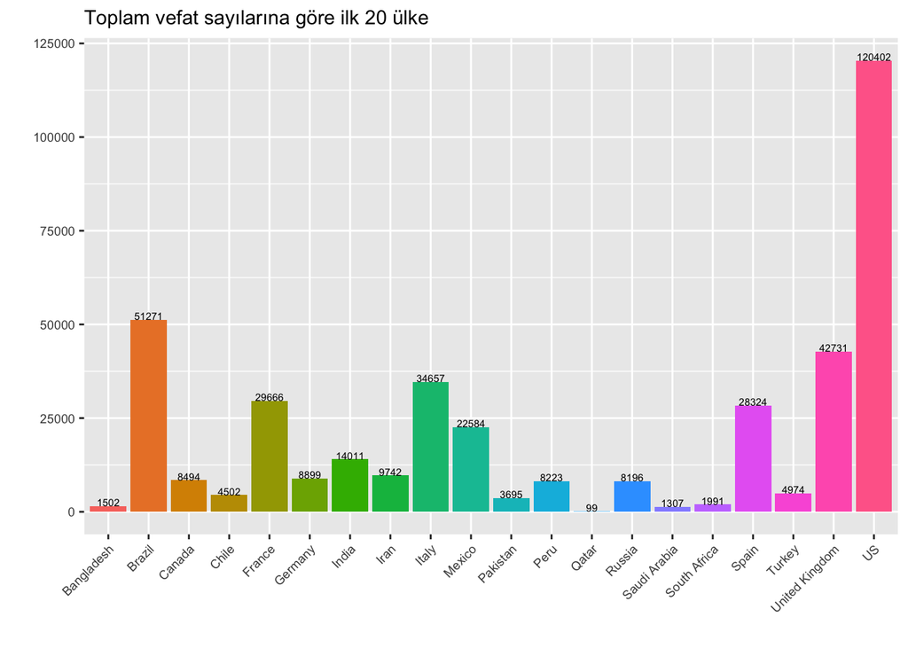

```r
ilk20[-1,] %>%  ggplot(aes(x=ulke,y=vefat.sayi,fill=ulke,group=ulke)) +
  geom_bar(stat = 'identity') + geom_text(aes(label=vefat.sayi,y=vefat.sayi),size=2,vjust=0) +
  xlab("") + ylab('') + labs(title = paste0('Toplam vefat sayılarına göre ilk 20 ülke ')) +
      scale_fill_discrete(name='ulke',labels=aes(vefat.sayi)) +
  theme(legend.title = element_blank(),legend.position = 'none',plot.title = element_text(size=11),axis.text = element_text(size=7),axis.text.x = element_text(angle=45,hjust = 1))
```

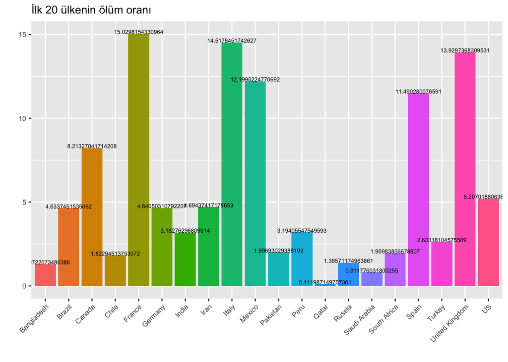

```r
ilk20[-1,] %>%  ggplot(aes(x=ulke,y=olum.oranı,fill=ulke,group=ulke)) +
  geom_bar(stat = 'identity') + geom_text(aes(label=olum.oranı,y=olum.oranı),size=2,vjust=0) +
  xlab("") + ylab('') + labs(title = paste0('İlk 20 ülkenin ölüm oranı ')) +
      scale_fill_discrete(name='ulke',labels=aes(olum.orani)) +
  theme(legend.title = element_blank(),legend.position = 'none',plot.title = element_text(size=11),axis.text = element_text(size=7),axis.text.x = element_text(angle=45,hjust = 1))
```

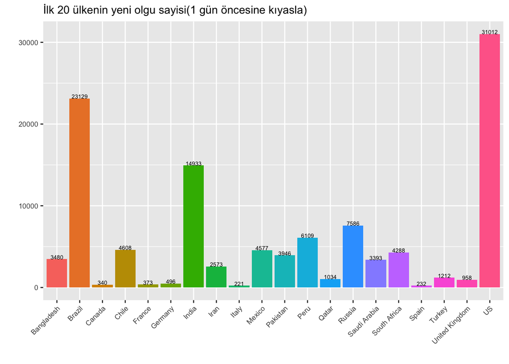

```r
ilk20[-1,] %>%  ggplot(aes(x=ulke,y=yeni.olgu,fill=ulke,group=ulke)) +
  geom_bar(stat = 'identity') + geom_text(aes(label=yeni.olgu,y=yeni.olgu),size=2,vjust=0) +
  xlab("") + ylab('') + labs(title = paste0('İlk 20 ülkenin yeni olgu sayisi(1 gün öncesine kıyasla) ')) +
      scale_fill_discrete(name='ulke',labels=aes(yeni.olgu)) +
  theme(legend.title = element_blank(),legend.position = 'none',plot.title = element_text(size=11),axis.text = element_text(size=7),axis.text.x = element_text(angle=45,hjust = 1))
```

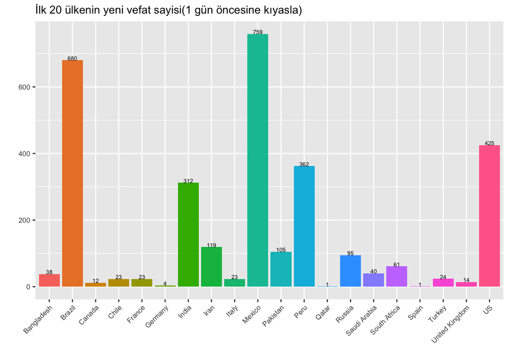

```r
ilk20[-1,] %>%  ggplot(aes(x=ulke,y=yeni.vefat,fill=ulke,group=ulke)) +
  geom_bar(stat = 'identity') + geom_text(aes(label=yeni.vefat,y=yeni.vefat),size=2,vjust=0) +
  xlab("") + ylab('') + labs(title = paste0('İlk 20 ülkenin yeni vefat sayisi(1 gün öncesine kıyasla) ')) +
      scale_fill_discrete(name='ulke',labels=aes(yeni.vefat)) +
  theme(legend.title = element_blank(),legend.position = 'none',plot.title = element_text(size=11),axis.text = element_text(size=7),axis.text.x = element_text(angle=45,hjust = 1))
```

## Kaynakça

$\bullet$ Manipulating Data-Converting data between wide and long format içinde. Erişim adresi http://www.cookbook-r.com/Manipulating_data/Converting_data_between_wide_and_long_format/

$\bullet$ Magrittr part of tidyverse-Overwiev içinde. Erişim adresi https://magrittr.tidyverse.org

$\bullet$ Lubridate part of tidyverse-Overwiev içinde. Erişim adresi https://lubridate.tidyverse.org

$\bullet$ Dplyr part of the tidyverse-Overwiev içinde. Erişim adresi https://dplyr.tidyverse.org/reference/mutate.html

$\bullet$ Dplyr part of the tidyverse-Group by one or more variables içinde. Erişim adresi https://dplyr.tidyverse.org/reference/group_by.html

$\bullet$ Using dplyr to group, manipulate and summarize data. Erişim adresi https://www3.nd.edu/~steve/computing_with_data/24_dplyr/dplyr.html

$\bullet$ Home/Courses /Earth analytics /Get data using apis /Creating Interactive Spatial Maps in R Using Leaflet içinde. Erişim adresi https://www.earthdatascience.org/courses/earth-analytics/get-data-using-apis/leaflet-r/